# My First Quarto Document

- Show All Code
- Hide All Code
- View Source

YAML, Markdown, and Code Chunks

Author

Your Name Here

Published

May 5, 2026

# 1 How to Create a Quarto Document

**Creating a Quarto Document in RStudio** To create a new Quarto document, open RStudio and go to File → New File → Quarto Document. A dialog box will appear asking for a title, author, and output format (HTML, PDF, or Word).Click Create, and RStudio will open a new .qmd file pre-populated with a short example.

Then paste this exactly into your new document:

```yaml
---
title: "My Report"
format:
  html:
    embed-resources: true
---
```

## 1.1 HTML

Hyper Text Markup Language (HTML) documents are commonly seen in web pages and web applications in the browser. They open easily on most any computer and can be hosted online. For this reason, we will focus on HTML documents as they are very flexible.

## 1.2 Render

When you click Render, Quarto runs every code chunk in your document from top to bottom in a fresh R session, which means it re-reads your dataset (e.g. read_csv(“oulad.csv”)), re-runs every calculation and plot against that current data, and weaves the results together with your prose into a finished output file (HTML, PDF, or Word).

### 1.2.1 Hard-coded or Dynamic

Since the render occurs at the click of a button, the document you create is always a live reflection of your current code and data. This means that you may want to consider using code that is dynamic if you anticipate rendering the document against a changing dataset.

# 2 YAML

YAML (rhymes with “camel”) stands for YAML Ain’t Markup Language — a simple, human-readable format for writing configuration settings as **key: value pairs**. In a Quarto document, the YAML header is the block at the very top, fenced by three dashes:

## 2.1 YAML Example

```yaml
---
title: "My First Quarto Document"
subtitle: "YAML, Markdown, and code chunks"
author: "Your Name Here"
date: today
format:
  html:
    embed-resources: true   # bundles CSS/JS into one self-contained .html file
    theme: lumen            # built-in Bootswatch theme — try cosmo, flatly, journal
    toc: true               # show a table of contents
    toc-location: right     # place the TOC on the right side
    number-sections: true   # auto-number each section
    code-fold: true         # hide code chunks behind a "Code" toggle
    code-tools: true
---
```

## 2.2 YAML Rules to remember:

- YAML is “white-space sensitive”.
- Indentation must be consistent (use spaces, not tabs).
- Nested options sit one level deeper than their parent.

# 3 Welcome to Quarto

Quarto reference documentation can be seen here: https://quarto.org/

Quarto is a document publishing system that lets you weave together prose and code to create reports, presentations, dashboards, websites, and books from your R scripts.These documents integrate your code and data to the extent that you want them to. They can dynamically update from your code and dataset, or be hard-coded to reflect static values.

## 3.1 Layout with Markdown

In a QUarto document, everything below the closing YAML `---` is the **body** of your document. The body is written in **Markdown** — a lightweight syntax that turns plain text into formatted HTML when you render the file.

**The Quarto Markdown Quick Reference**

You can access a quick guide here: https://quarto.org/docs/authoring/markdown-basics.html

## 3.2 Headings

This section walks through the most common Markdown patterns you’ll use.

Use `#` symbols at the start of a line to create headings. The number of `#` controls the level:

- `#` is a top-level heading (like the section title above)
- `##` is a subsection
- `###` is a sub-subsection
- And so on, down to `######`

## 3.3 Emphasis: bold and italic

You make text **bold** by wrapping it in `**double asterisks**`. You make text *italic* by wrapping it in `*single asterisks*`. You can even combine them for *bold italic*.

## 3.4 Lists

A bulleted list uses dashes:

- First item
- Second item
- Third item

A numbered list uses numbers (Markdown auto-renumbers, so you can write `1.` for every line if you want):

1. Read the data
2. Clean the data
3. Visualize the data
4. Write up findings

## 3.5 Links and images

Links use this pattern: `[link text](url)`. For example, visit the [Quarto documentation](https://quarto.org) to learn more.

Images use almost the same pattern, with a `!` in front. You just drop them in the folder with your QMD file and it will grab it on render. `![alt text](path/to/image.png)`

I used `![Here is a plant](plant.jpg)` to render the plant here:

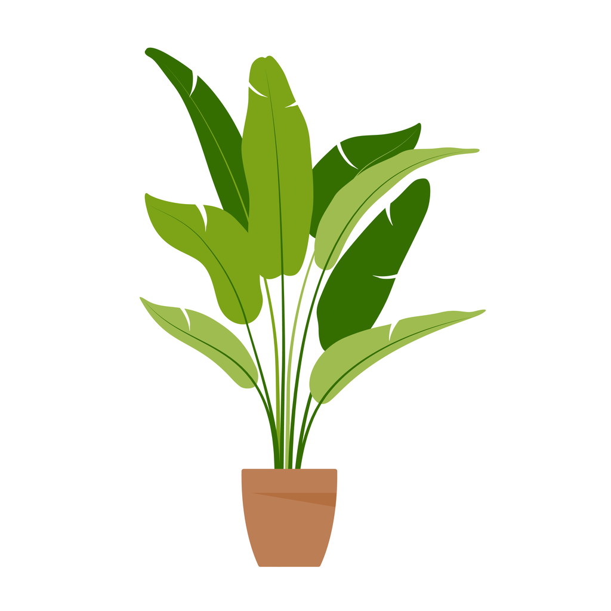

## 3.6 Inline code and code blocks

Wrap a word in single backticks to format it as `inline code` — useful for variable names, function names, and file paths.

For longer code samples that you want shown but NOT executed, use three backticks with a language name:

```r
mean(c(1, 2, 3, 4, 5))
```

# 4 Executable Code Chunks

Quarto runs code chunks when you render. These look like fenced code blocks but use curly braces around the language name. The result (a number, table, or plot) appears in the final document.

```r
# This is a comment inside an R chunk.
2 + 2
```

```
[1] 4
```

The `#|` lines at the top of a chunk are **chunk options** — they control whether code shows, whether warnings appear, the figure size, and so on. Common ones:

- `echo: false` — hide the code, show only the result
- `eval: false` — show the code but don’t run it
- `include: false` — run the code but hide everything (useful for setup)
- `fig-width: 6` and `fig-height: 4` — control plot dimensions

## 4.1 A Visualization Chunk

One of the most important aspects of working in Quarto is that it allows us to access our datasets and render outputs such as data visualizations directly with code.

The `mtcars` dataset is built into R — it has specs for 32 cars from a 1974 *Motor Trend* issue. We’ll use it for a quick example with ggplot.

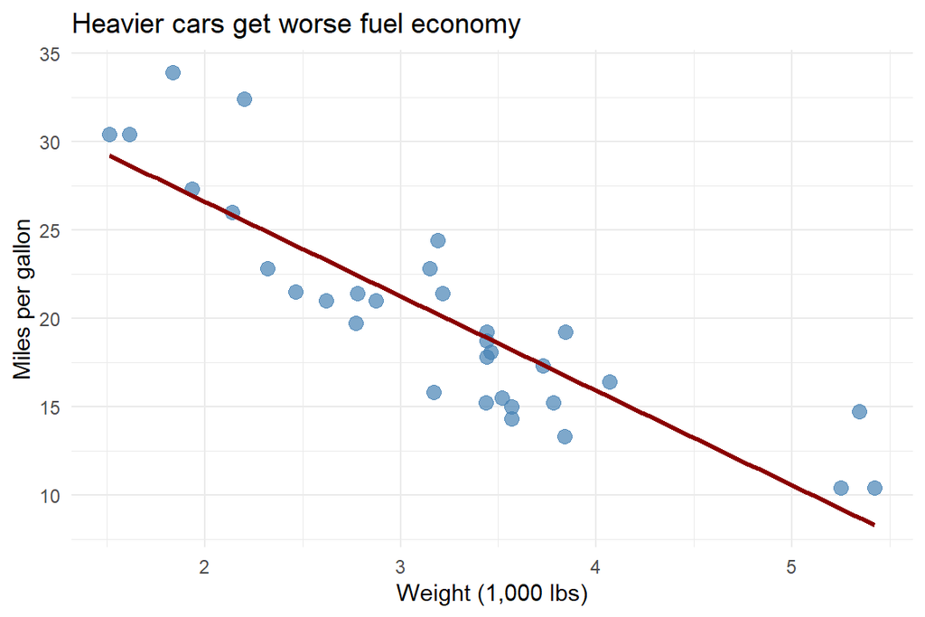

```r
library(tidyverse)

ggplot(mtcars, aes(x = wt, y = mpg)) +
  geom_point(color = "steelblue", size = 3, alpha = 0.7) +
  geom_smooth(method = "lm", se = FALSE, color = "darkred") +
  labs(title = "Heavier cars get worse fuel economy",
       x = "Weight (1,000 lbs)", y = "Miles per gallon") +
  theme_minimal()
```

# 5 Callout Boxes (the `:::` syntax)

Those colored boxes you see in nice-looking reports are called **callouts**. They use a special syntax of three colons to open, three colons to close. Quarto includes with five built-in callout types.

**Note**

This is a **note** callout. Use it for general asides, definitions, or context the reader might want but doesn’t strictly need.

**Tip**

This is a **tip** callout. Use it for helpful suggestions, shortcuts, or “did you know” content.

**Warning**

This is a **warning** callout. Use it to flag something the reader should be careful about — a common mistake, a data caveat, an assumption that might not hold.

**Important**

This is an **important** callout. Stronger than a warning — use it for things the reader absolutely must not miss.

**Caution**

This is a **caution** callout. Similar to warning, often used for methodological concerns or “interpret with care” notes.

You can give a callout a custom title:

**A note about callouts**

This clarifies the purpose of the callout.

You can also make them collapsible which is helpful for hiding lengthy methodological details that only some readers want to see.

**Click to expand: Detailed Info**

You can put lengthy information inside here so it can be collapsed.

# 6 Tables

**How it works:** The first row is your header. The second row (the dashes) tells Quarto “this is a table” and separates the header from the body. Every row after that is data. The pipes | are the column separators. You don’t have to align the pipes perfectly — Markdown doesn’t care about whitespace inside cells, so this messier version renders identically:

## 6.1 Clean formatting in the Quarto…

| Module | Students | Pass Rate |
| --- | --- | --- |
| AAA | 748 | 64% |
| BBB | 7,909 | 48% |
| CCC | 4,434 | 41% |
| DDD | 6,272 | 45% |

## 6.2 Renders the same as messy Quarto formatting.

| Module | Students | Pass Rate |
| --- | --- | --- |
| AAA | 748 | 64% |
| BBB | 7,909 | 48% |

## 6.3 You can control alignment with “:”

:— left-aligns, —: right-aligns, :—: centers.

| Module | Students | Pass Rate |
| --- | --- | --- |
| AAA | 748 | 64% |
| BBB | 7,909 | 48% |

## 6.4 Highlighting a single cell with color

Markdown doesn’t have built-in syntax for cell colors, but Quarto extends markdown with a feature called a **bracketed span** that lets you wrap text in styling. The pattern is `[text]{style="..."}` — whatever you put inside the brackets gets the styling listed inside the curly braces.

| Module | Students | Pass Rate |
| --- | --- | --- |
| AAA | 748 | 64% |
| BBB | 7,909 | 48% |
| CCC | 4,434 | 41% |
| DDD | 6,272 | 45% |

The green cell highlights a strong pass rate, the red one flags a weak one. The `style="background-color:..."` part is just CSS — any valid color name (`lightgreen`, `salmon`) or hex code (`#d4efdf`) works.

> **Heads up:** the highlight only colors the text background inside the cell, not the entire cell to its edges. For most reports that looks fine. If you need fully colored cells with conditional logic, use the `gt` package instead.

## 6.5 Grouping rows visually

Markdown doesn’t have true row groups like spreadsheets do, but you can fake them by inserting a “group header” row that spans the table and introduces the rows below it. Use bold text to make the group label stand out:

[output not shown]

You can combine the two — color the group header rows to make them stand out even more:

[output not shown]

These tricks work well for tables you write by hand in your prose. If your table is generated from data — for example, a summary of all modules with conditional formatting based on each value — you may want to use the `gt` package, which applies these rules programmatically.

# 7 Tips

1. **Render often.** Small renders catch small errors. Don’t write 100 lines of Markdown and a dozen code chunks before checking that it builds.
2. **Watch your YAML indentation.** Most “weird” Quarto errors trace back to a misaligned text in the YAML.
3. **Keep code chunks small and labeled.** A `#| label: my-chunk` line at the top makes errors much easier to find.
4. **Use callouts sparingly.** A page full of colored boxes loses its emphasis — they work because they’re rare.